### Data Preparation

#### Step1: Data Acquisition

```r
library(readr)
X2015 <- read_csv("/Users/apple/OneDrive - Northeastern University/MATH7343/project/2015.csv")
```

#### Step2: Explore data

*1. summary*

```r
summary(X2015)
```

```
##  Happiness Score Economy (GDP per Capita)     Family
##  Min.   :2.839   Min.   :0.0000           Min.   :0.0000
##  1st Qu.:4.526   1st Qu.:0.5458           1st Qu.:0.8568
##  Median :5.232   Median :0.9102           Median :1.0295
##  Mean   :5.376   Mean   :0.8461           Mean   :0.9910
##  3rd Qu.:6.244   3rd Qu.:1.1584           3rd Qu.:1.2144
##  Max.   :7.587   Max.   :1.6904           Max.   :1.4022
##  Health (Life Expectancy)    Freedom       Trust (Government Corruption)
##  Min.   :0.0000           Min.   :0.0000   Min.   :0.00000
##  1st Qu.:0.4392           1st Qu.:0.3283   1st Qu.:0.06168
##  Median :0.6967           Median :0.4355   Median :0.10722
##  Mean   :0.6303           Mean   :0.4286   Mean   :0.14342
##  3rd Qu.:0.8110           3rd Qu.:0.5491   3rd Qu.:0.18025
##  Max.   :1.0252           Max.   :0.6697   Max.   :0.55191
##    Generosity     Dystopia Residual
##  Min.   :0.0000   Min.   :0.3286
##  1st Qu.:0.1506   1st Qu.:1.7594
##  Median :0.2161   Median :2.0954
##  Mean   :0.2373   Mean   :2.0990
##  3rd Qu.:0.3099   3rd Qu.:2.4624
##  Max.   :0.7959   Max.   :3.6021
```

#### Step3: Deal with missing values:

```r
sapply(X2015, function(x) sum(is.na (X2015)))
```

```
##               Happiness Score      Economy (GDP per Capita)
##                             0                             0
##                        Family      Health (Life Expectancy)
##                             0                             0
##                       Freedom Trust (Government Corruption)
##                             0                             0
##                    Generosity             Dystopia Residual
##                             0                             0
```

There are no na value. good.

#### Step4: ouliers

We use boxplot to drop the points below Q1 - 1.5 * IQR or above Q3 + 1.5 * IQR.

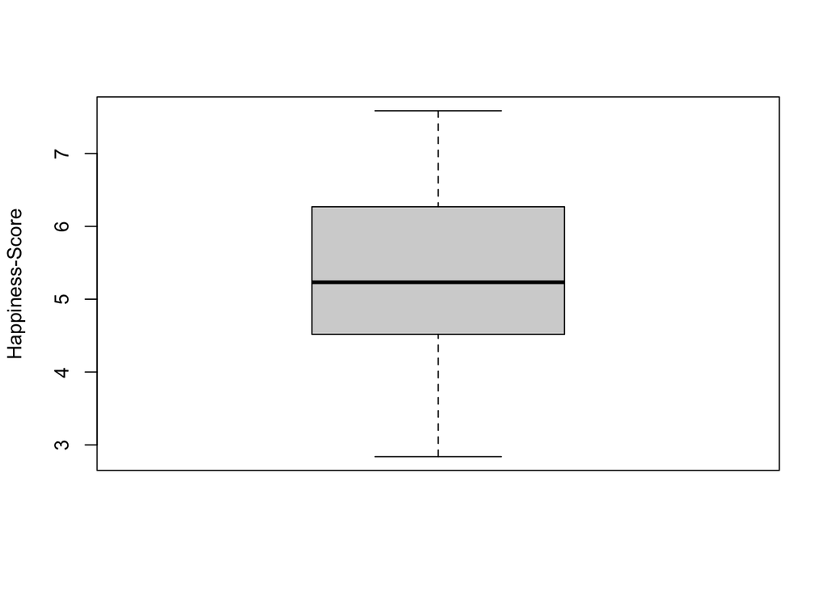

```r
bx1<-boxplot(X2015$`Happiness Score`, ylab = "Happiness-Score")
```

no outliers for column 1.

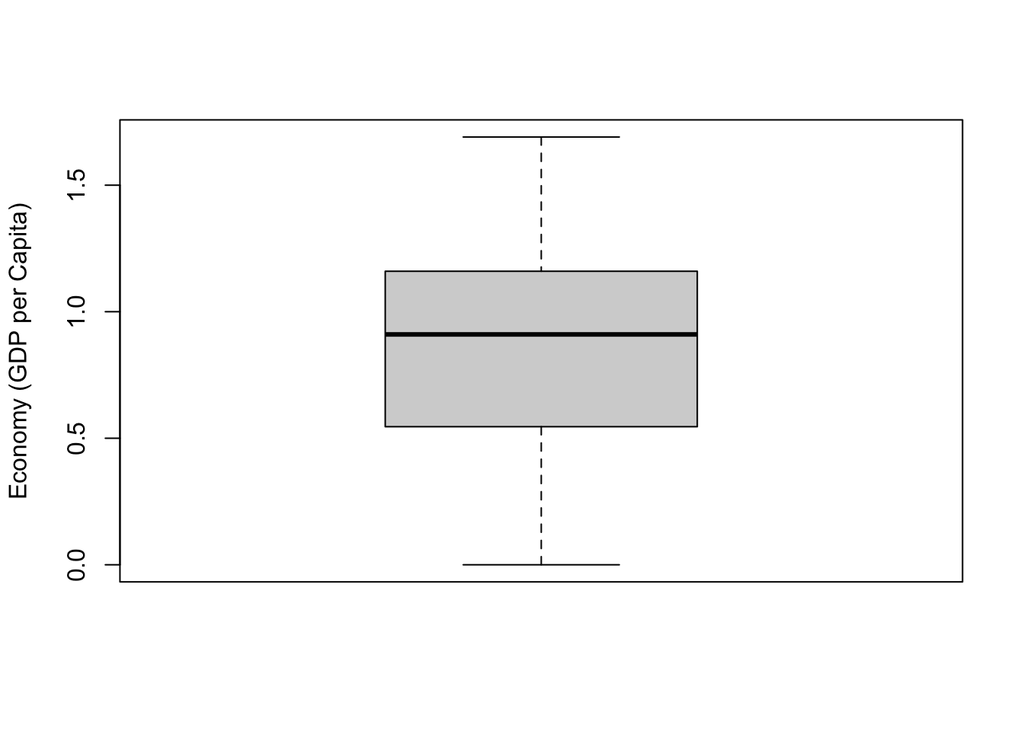

```r
bx2<-boxplot(X2015$`Economy (GDP per Capita)`, ylab = "Economy (GDP per Capita)")
```

no outliers for column 2.

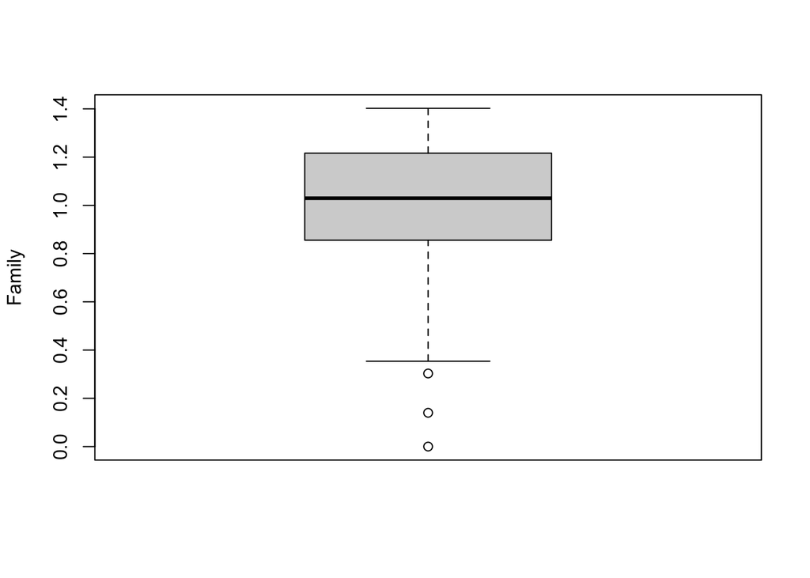

```r
bx3<-boxplot(X2015$Family, ylab = "Family")
```

3 outliers!

```r
out_ind3 <- which( X2015$Family%in% bx3$out)
X2015_no<-X2015[-out_ind3,]
dim(X2015_no)
```

```
## [1] 155   8
```

```r
dim(X2015)
```

```
## [1] 158   8
```

ok, delete the outliers for coolumn3!

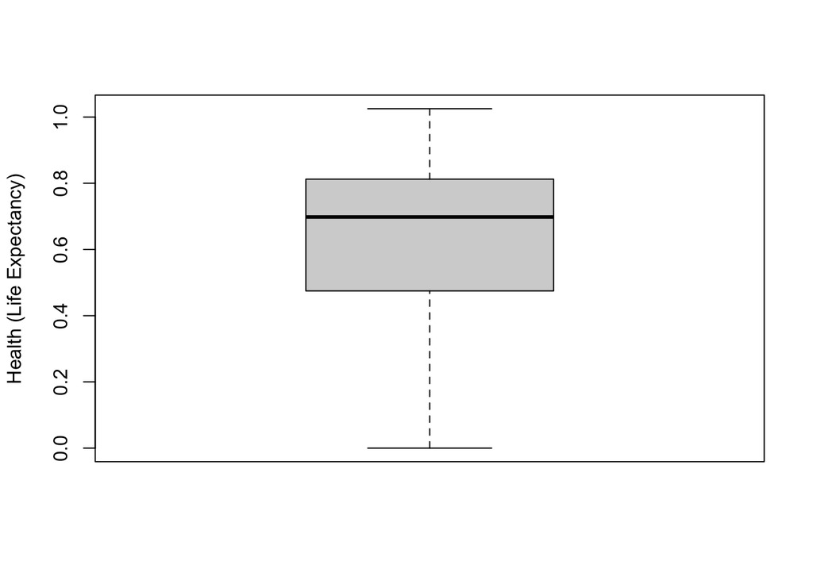

```r
bx4<-boxplot(X2015_no$`Health (Life Expectancy)`, ylab = "Health (Life Expectancy)")
```

no outliers!

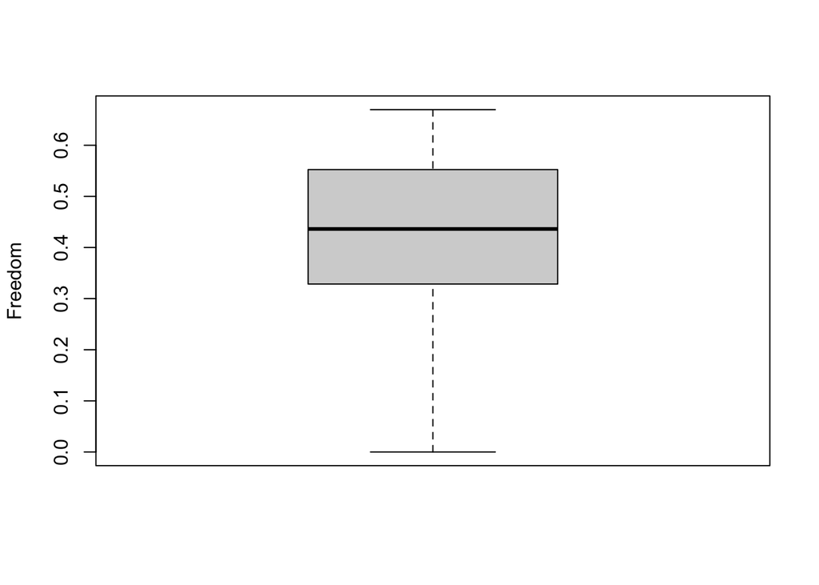

```r
bx5<-boxplot(X2015_no$Freedom, ylab = "Freedom")
```

no outliers!

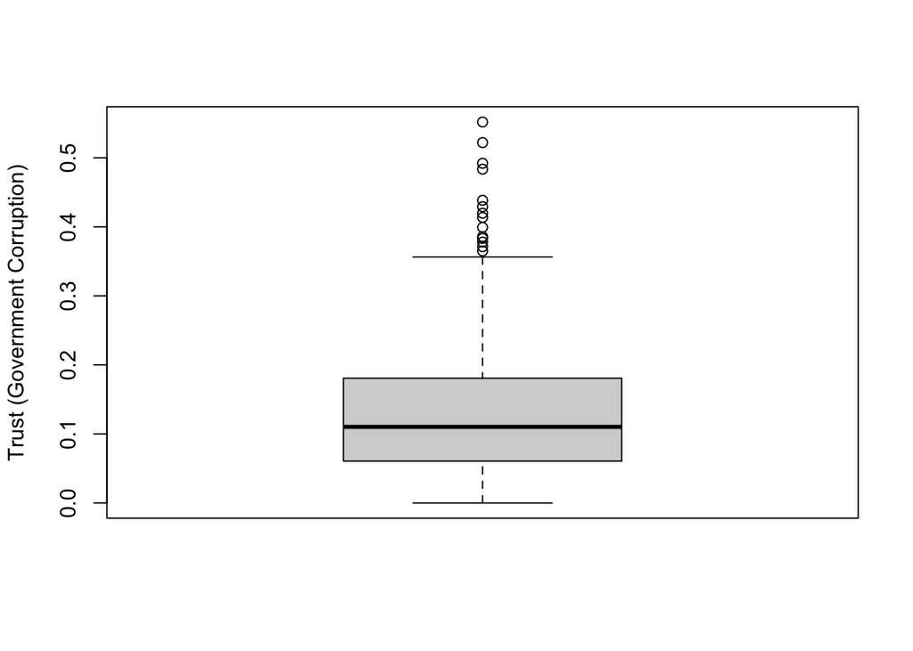

```r
bx6<-boxplot(X2015_no$`Trust (Government Corruption)`, ylab = "Trust (Government Corruption)")
```

many outliers!

```r
out_ind6 <- which( X2015_no$`Trust (Government Corruption)`%in% bx6$out)
X2015_no<-X2015_no[-out_ind6,]
dim(X2015_no)
```

```
## [1] 141   8
```

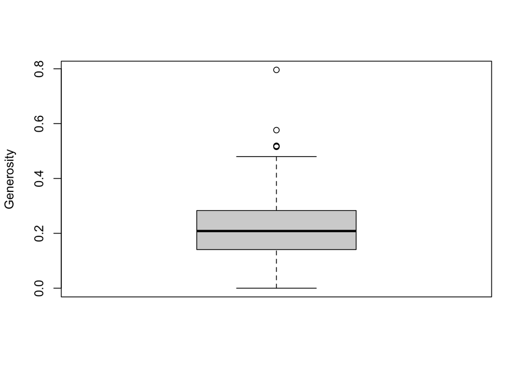

```r
bx7<-boxplot(X2015_no$Generosity, ylab = "Generosity")
```

some outlier!

```r
out_ind7 <- which( X2015_no$Generosity%in% bx7$out)
X2015_no<-X2015_no[-out_ind7,]
dim(X2015_no)
```

```
## [1] 136   8
```

delete all the outliers now!!!

#### Step5: correlation/collinearity/distribution analysis

Use pairs.panels to see the distributions and correlation of each feature in the data set.

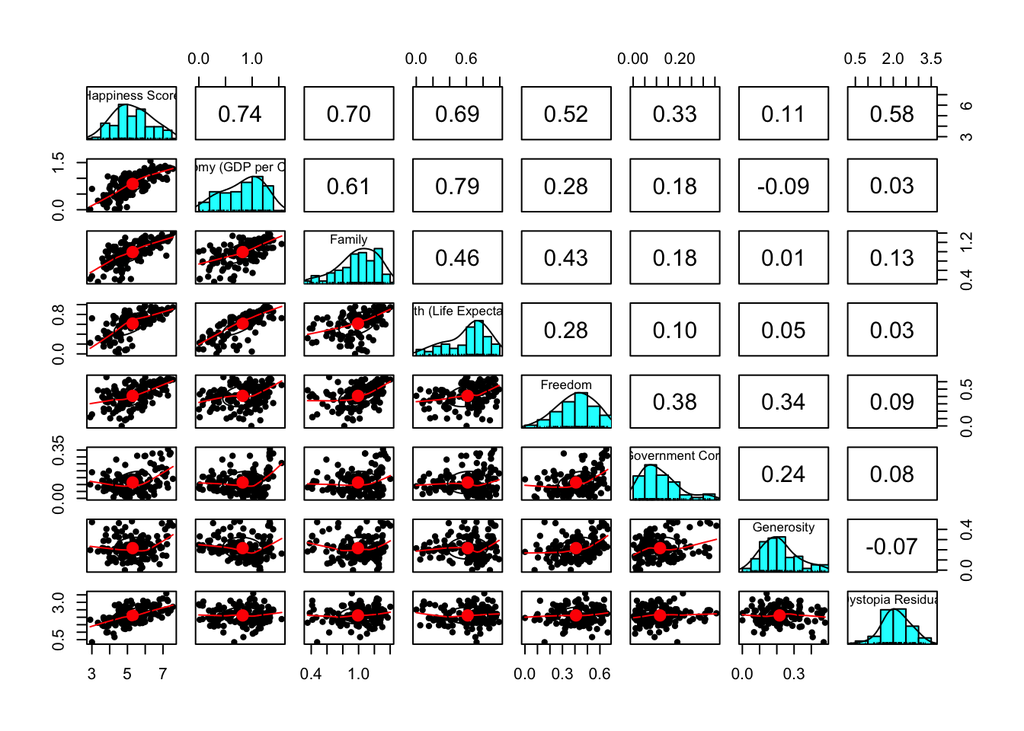

```r
library(psych)
pairs.panels(X2015_no,method = "pearson")
```

```r
cc = cor(X2015_no, method = "spearman")
cc
```

```
##                               Happiness Score Economy (GDP per Capita)
## Happiness Score                    1.00000000               0.75184957
## Economy (GDP per Capita)           0.75184957               1.00000000
## Family                             0.71324926               0.63651066
## Health (Life Expectancy)           0.71349104               0.81890036
## Freedom                            0.50907460               0.30212299
## Trust (Government Corruption)      0.22611332               0.09486677
## Generosity                         0.05081586              -0.13278947
## Dystopia Residual                  0.56693451               0.05272649
##                                   Family Health (Life Expectancy)   Freedom
## Happiness Score               0.71324926              0.713491039 0.5090746
## Economy (GDP per Capita)      0.63651066              0.818900361 0.3021230
## Family                        1.00000000              0.517127662 0.4690187
## Health (Life Expectancy)      0.51712766              1.000000000 0.2891922
## Freedom                       0.46901865              0.289192177 1.0000000
## Trust (Government Corruption) 0.12836951              0.013286612 0.3569991
## Generosity                    0.03219312             -0.007733419 0.3275321
## Dystopia Residual             0.14155813              0.071730919 0.0953819
##                               Trust (Government Corruption)   Generosity
## Happiness Score                                  0.22611332  0.050815861
## Economy (GDP per Capita)                         0.09486677 -0.132789466
## Family                                           0.12836951  0.032193121
## Health (Life Expectancy)                         0.01328661 -0.007733419
## Freedom                                          0.35699914  0.327532083
## Trust (Government Corruption)                    1.00000000  0.121573543
## Generosity                                       0.12157354  1.000000000
## Dystopia Residual                                0.10956790  0.029125519
##                               Dystopia Residual
## Happiness Score                      0.56693451
## Economy (GDP per Capita)             0.05272649
## Family                               0.14155813
## Health (Life Expectancy)             0.07173092
## Freedom                              0.09538190
## Trust (Government Corruption)        0.10956790
## Generosity                           0.02912552
## Dystopia Residual                    1.00000000
```

#### Step6: normalization

```r
X2015_no
```

```
## # A tibble: 136 x 8
##    `Happiness Scor… `Economy (GDP p… Family `Health (Life E… Freedom
##               <dbl>            <dbl>  <dbl>            <dbl>   <dbl>
##  1             7.56            1.30   1.40             0.948   0.629
##  2             7.43            1.33   1.32             0.906   0.633
##  3             7.38            1.33   1.28             0.893   0.616
##  4             7.28            1.33   1.31             0.932   0.651
##  5             7.28            1.23   1.22             0.914   0.413
##  6             7.23            0.956  1.24             0.860   0.634
##  7             7.2             1.34   1.30             0.890   0.624
##  8             7.19            1.02   0.915            0.814   0.482
##  9             7.12            1.39   1.25             0.862   0.546
## 10             6.98            0.981  1.23             0.697   0.490
## # … with 126 more rows, and 3 more variables: `Trust (Government
## #   Corruption)` <dbl>, Generosity <dbl>, `Dystopia Residual` <dbl>
```

```r
X2015_scaled<-X2015_no
X2015_scaled
```

```
## # A tibble: 136 x 8
##    `Happiness Scor… `Economy (GDP p… Family `Health (Life E… Freedom
##               <dbl>            <dbl>  <dbl>            <dbl>   <dbl>
##  1             7.56            1.30   1.40             0.948   0.629
##  2             7.43            1.33   1.32             0.906   0.633
##  3             7.38            1.33   1.28             0.893   0.616
##  4             7.28            1.33   1.31             0.932   0.651
##  5             7.28            1.23   1.22             0.914   0.413
##  6             7.23            0.956  1.24             0.860   0.634
##  7             7.2             1.34   1.30             0.890   0.624
##  8             7.19            1.02   0.915            0.814   0.482
##  9             7.12            1.39   1.25             0.862   0.546
## 10             6.98            0.981  1.23             0.697   0.490
## # … with 126 more rows, and 3 more variables: `Trust (Government
## #   Corruption)` <dbl>, Generosity <dbl>, `Dystopia Residual` <dbl>
```

```r
#use scale function to normalize all the columns except the target
X2015_scaled <- as.data.frame(scale(X2015_scaled[,-1]))
X2015_scaled$Happyiness<-X2015_no$`Happiness Score`
X2015_scaled
```

```
##     Economy (GDP per Capita)      Family Health (Life Expectancy)       Freedom
## 1                 1.28609477  1.69191654              1.377958628  1.5069583529
## 2                 1.35023273  1.36353446              1.202975729  1.5356820626
## 3                 1.35866137  1.18849633              1.149954377  1.4179832426
## 4                 1.36973902  1.30835043              1.310469370  1.6606301999
## 5                 1.08875751  0.95654194              1.237134912  0.0326113673
## 6                 0.35883706  1.01407686              1.014934405  1.5410848556
## 7                 1.37950554  1.25807440              1.139922190  1.4765932883
## 8                 0.53211925 -0.31961962              0.824944681  0.5019020721
## 9                 1.53277305  1.05214476              1.021235613  0.9411696614
## 10                0.42696190  0.99341378              0.338176332  0.5612644055
## 11                1.37610733  1.55684353              1.160276751  1.4317295894
## 12                1.30081145  1.21113910              1.165831764  1.2041967746
## 13                1.44072692  0.37042818              0.610703595  1.5341090976
## 14                0.59553475  1.08864541              0.435596330  0.1412827357
```

[output cut: 259 more lines]

check out if the columns have been normalized.

```r
summary(X2015_scaled)
```

```
##  Economy (GDP per Capita)     Family        Health (Life Expectancy)
##  Min.   :-2.1986          Min.   :-2.6319   Min.   :-2.5513
##  1st Qu.:-0.7369          1st Qu.:-0.5477   1st Qu.:-0.7481
##  Median : 0.1902          Median : 0.1038   Median : 0.2775
##  Mean   : 0.0000          Mean   : 0.0000   Mean   : 0.0000
##  3rd Qu.: 0.8066          3rd Qu.: 0.8554   3rd Qu.: 0.7130
##  Max.   : 1.9601          Max.   : 1.6919   Max.   : 1.5573
##     Freedom        Trust (Government Corruption)   Generosity
##  Min.   :-2.7932   Min.   :-1.4012               Min.   :-2.0283
##  1st Qu.:-0.6338   1st Qu.:-0.7024               1st Qu.:-0.7382
##  Median : 0.0506   Median :-0.2662               Median :-0.1176
##  Mean   : 0.0000   Mean   : 0.0000               Mean   : 0.0000
##  3rd Qu.: 0.7650   3rd Qu.: 0.4927               3rd Qu.: 0.5345
##  Max.   : 1.7374   Max.   : 2.9942               Max.   : 2.4781
##  Dystopia Residual   Happyiness
##  Min.   :-3.2584   Min.   :2.905
##  1st Qu.:-0.6240   1st Qu.:4.542
##  Median :-0.0293   Median :5.166
##  Mean   : 0.0000   Mean   :5.292
##  3rd Qu.: 0.6260   3rd Qu.:5.977
##  Max.   : 2.6852   Max.   :7.561
```

```r
data<-X2015_scaled
names(data)<-c("GDP","Family","Health","Freedom","Trust","Generosity","Dystopia","score")
data
```

```
##             GDP      Family       Health       Freedom       Trust   Generosity
## 1    1.28609477  1.69191654  1.377958628  1.5069583529  0.32640555  2.067961761
## 2    1.35023273  1.36353446  1.202975729  1.5356820626  2.66154738  2.272725938
## 3    1.35866137  1.18849633  1.149954377  1.4179832426  2.51966629  2.441625871
## 4    1.36973902  1.30835043  1.310469370  1.6606301999  2.99421696  2.061577550
## 5    1.08875751  0.95654194  1.237134912  0.0326113673 -0.46306404  1.086107673
## 6    0.35883706  1.01407686  1.014934405  1.5410848556 -0.11574707  0.365536806
## 7    1.37950554  1.25807440  1.139922190  1.4765932883  0.88884058  1.078221295
## 8    0.53211925 -0.31961962  0.824944681  0.5019020721  1.21604841 -0.706916746
## 9    1.53277305  1.05214476  1.021235613  0.9411696614  0.54301317  1.737015532
## 10   0.42696190  0.99341378  0.338176332  0.5612644055  0.74546992 -0.659974019
## 11   1.37610733  1.55684353  1.160276751  1.4317295894  2.13349649  2.281175629
## 12   1.30081145  1.21113910  1.165831764  1.2041967746  1.36848059  0.060690734
## 13   1.44072692  0.37042818  0.610703595  1.5341090976  2.60779890 -0.005780168
## 14   0.59553475  1.08864541  0.435596330  0.1412827357 -0.05541968 -1.479875697
```

[output cut: 259 more lines]

#### Split the data into training data and testing data

Choose 70% of the data randomly to be the training data, the left data to be the testing data.

```r
set.seed(123123)
splitsample <- sample.int(n = nrow(data), size = floor(.70*nrow(data)), replace = F)
train <- data[splitsample, ]
test <- data[-splitsample, ]
head(train)
```

```
##            GDP      Family     Health     Freedom       Trust  Generosity
## 115 -1.0680920 -0.43031763 -1.5812049  0.57904575 -0.71120079 -0.09253033
## 11   1.3761073  1.55684353  1.1602768  1.43172959  2.13349649  2.28117563
## 24   1.0928782  1.32715754  1.4102109  0.34939285 -0.63523296 -0.31701045
## 77   0.2591115  0.04254102  0.4974891 -0.50506912 -0.76817666  0.07092425
## 54   1.0340650 -0.40759237  1.2773051 -0.01163682 -0.66651383  0.84820193
## 75  -0.3113337  0.17798523 -0.1422079  1.48425294  0.09477815  0.31803077
##          Dystopia score
## 115 -0.3132113918 4.252
## 11  -0.2678383923 6.940
## 24   0.0008227815 6.329
## 77  -0.6970026934 5.007
## 54  -0.4246920707 5.689
## 75  -0.6710934216 5.073
```

```r
train<-as.data.frame(train)
test<-as.data.frame(test)
```

#### Model1: Linear Regression

*1.build the model*

There are four assumptions of linear regression.

1.1 Linear relationship: It means there exists a linear relationship between the independent variable, x, and the dependent variable, y.

We can check linearity using the scatterplots.

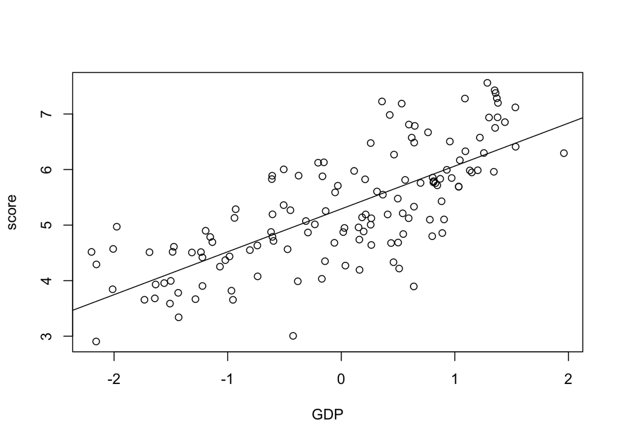

```r
plot(score ~ GDP, data=data)
abline(lm(score ~ GDP, data=data))
```

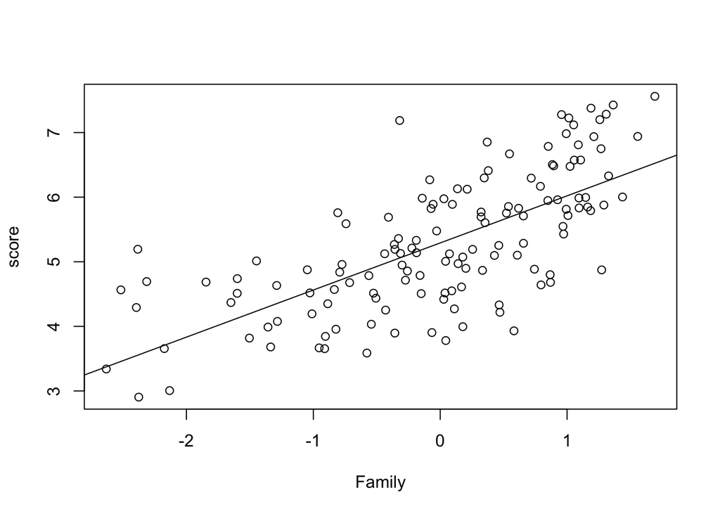

```r
plot(score ~ Family, data=data)
abline(lm(score ~ Family, data=data))
```

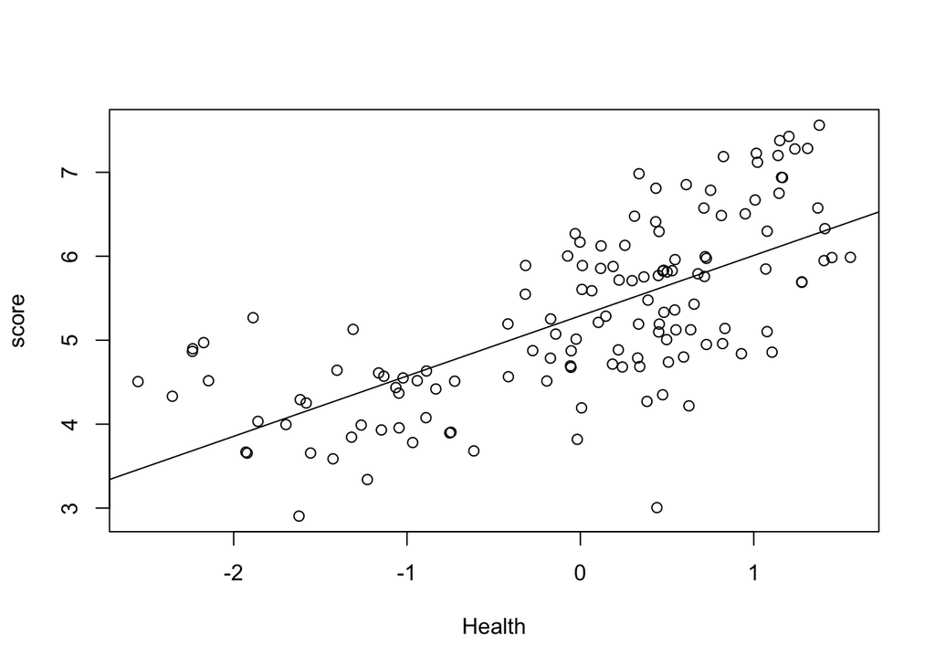

```r
plot(score ~ Health, data=data)
abline(lm(score ~ Health, data=data))
```

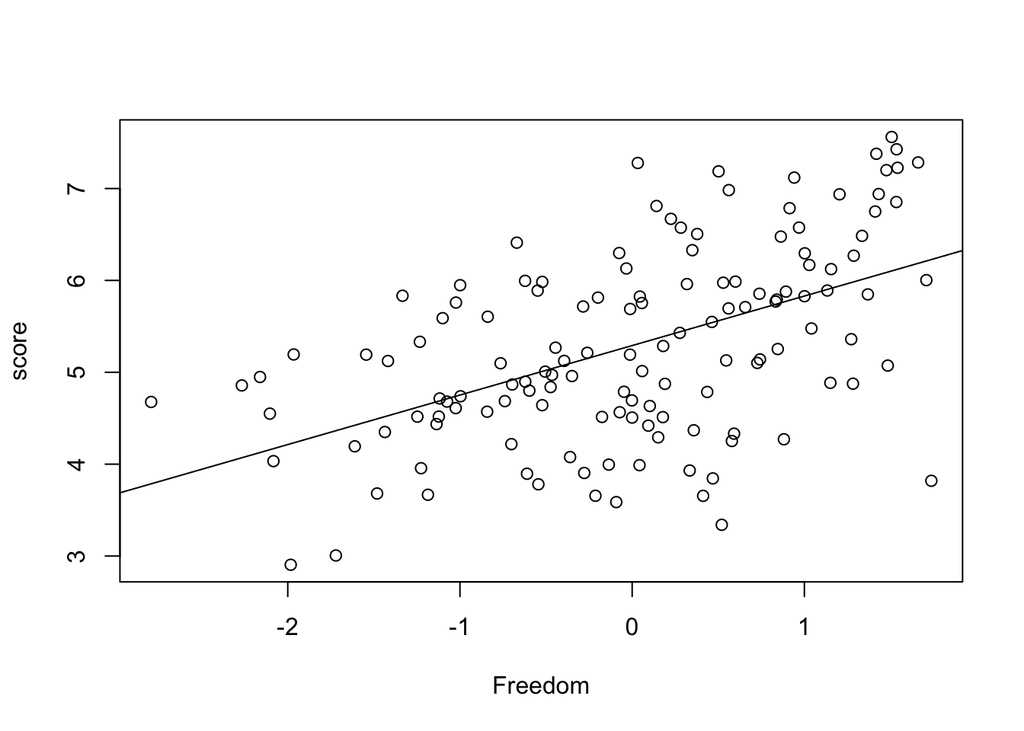

```r
plot(score ~ Freedom, data=data)
abline(lm(score ~ Freedom, data=data))
```

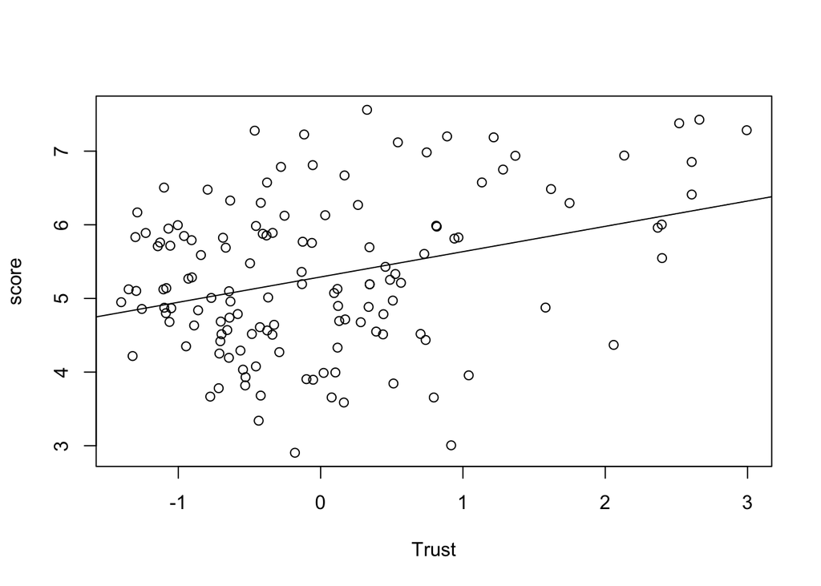

```r
plot(score ~ Trust, data=data)
abline(lm(score ~ Trust, data=data))
```

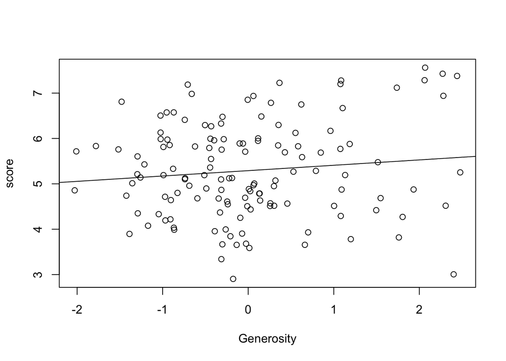

```r
plot(score ~ Generosity, data=data)
abline(lm(score ~ Generosity, data=data))
```

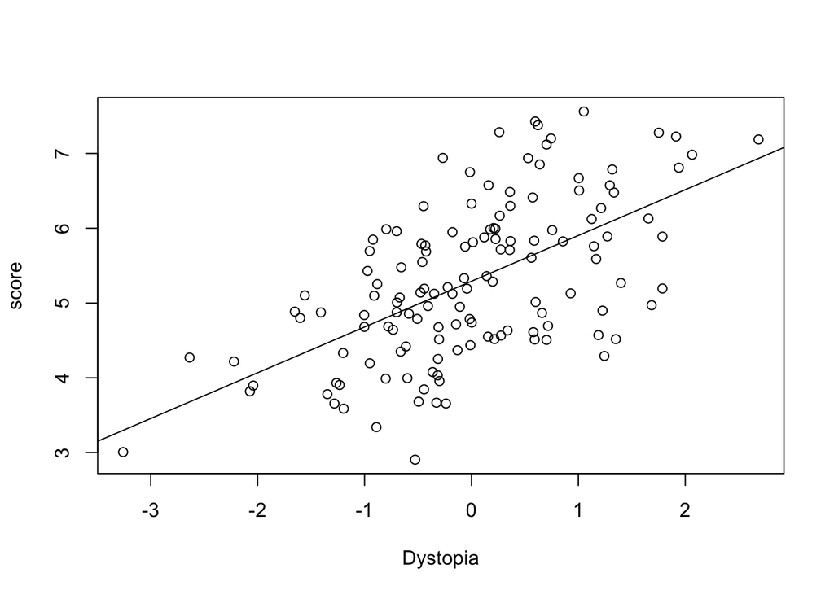

```r
plot(score ~ Dystopia, data=data)
abline(lm(score ~ Dystopia, data=data))
```

From the plots above, the linear relationship is not good in variable Generosity, for other variables it is good.

1.2 Independence: It means the residuals are independent.

It is not a longitudinal data set so we do not need to worry about independence assumption. It is “assumed” to be met.

1.3 Homoscedasticity: It means the residuals have constant variance at every level of x.

1.4 Normality: It means the residuals of the model are normally distributed.

We will check 1.3 and 1.4 later.

```r
lm1 = lm(score~., data =train) #Create the linear regression
summary(lm1)
```

```
##
## Call:
## lm(formula = score ~ ., data = train)
##
## Residuals:
##        Min         1Q     Median         3Q        Max
## -5.486e-04 -2.176e-04 -2.703e-05  2.417e-04  5.585e-04
##
## Coefficients:
##              Estimate Std. Error t value Pr(>|t|)
## (Intercept) 5.292e+00  3.034e-05  174425   <2e-16 ***
## GDP         3.738e-01  5.764e-05    6485   <2e-16 ***
## Family      2.425e-01  3.962e-05    6120   <2e-16 ***
## Health      2.411e-01  5.154e-05    4679   <2e-16 ***
## Freedom     1.462e-01  3.704e-05    3947   <2e-16 ***
## Trust       8.053e-02  3.772e-05    2135   <2e-16 ***
## Generosity  1.065e-01  3.257e-05    3271   <2e-16 ***
## Dystopia    5.508e-01  2.946e-05   18695   <2e-16 ***
## ---
## Signif. codes:  0 '***' 0.001 '**' 0.01 '*' 0.05 '.' 0.1 ' ' 1
##
## Residual standard error: 0.0002934 on 87 degrees of freedom
## Multiple R-squared:      1,  Adjusted R-squared:      1
## F-statistic: 1.881e+08 on 7 and 87 DF,  p-value: < 2.2e-16
```

*2.evaluate the model*

With R-square of 1, the model is good but we are concerned about overfitting.

```r
pred_lr <- predict(lm1, newdata = test)
sst_lr <- sum((test[,8] - mean(test[,8]))^2)
sse_lr <- sum((pred_lr - test[,8])^2)
mse_lr<-mean((pred_lr - test[,8])^2)
mse_lr
```

```
## [1] 8.452302e-08
```

```r
rmse_lr<-sqrt(mse_lr)
rmse_lr
```

```
## [1] 0.0002907284
```

```r
# R squared
rsq_lr <- 1 - sse_lr / sst_lr
rsq_lr
```

```
## [1] 0.9999999
```

The r-squared for testing data is 0.9999, not bad. The mse is 8.452302e-08. The rmse is 0.0002907284.

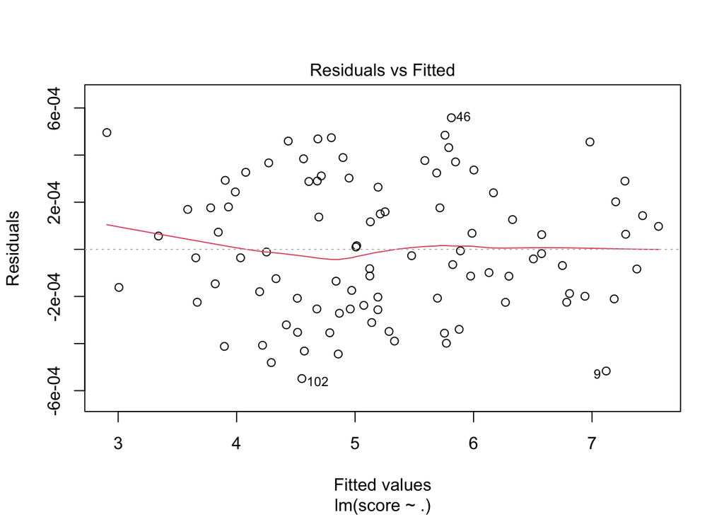

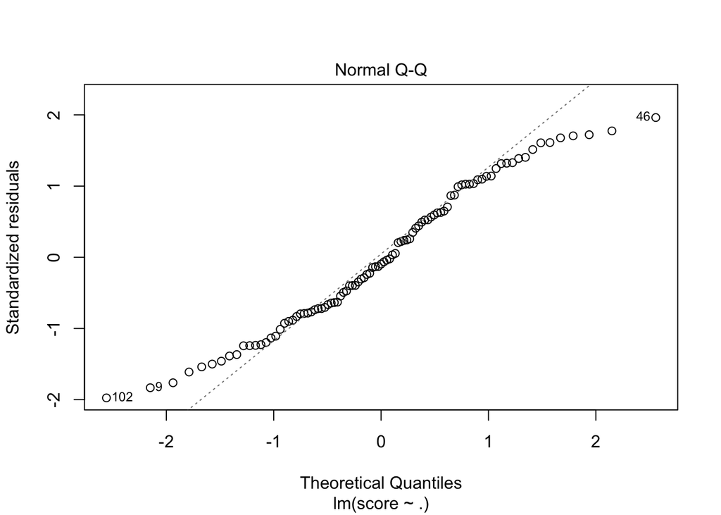

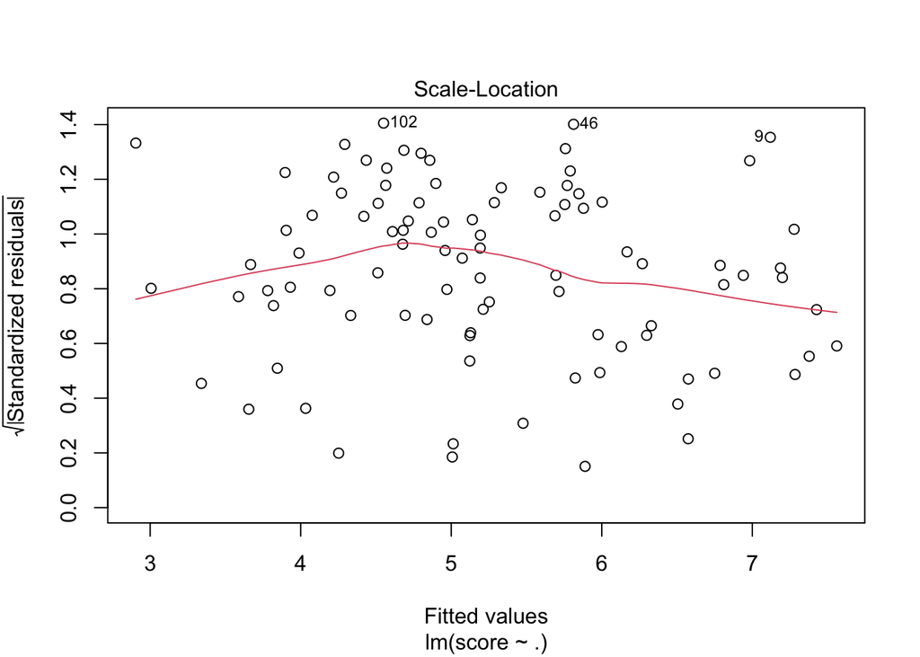

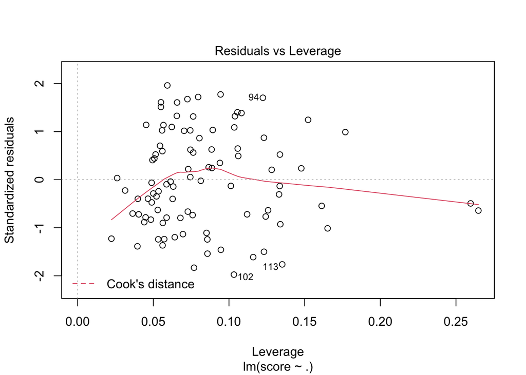

```r
plot(lm1)
```

From the plot:

1. Residuals vs Fitted

This plot shows if residuals have non-linear patterns. There could be a non-linear relationship between predictor variables and an outcome variable and the pattern could show up in this plot if the model doesn’t capture the non-linear relationship. If you find equally spread residuals around a horizontal line without distinct patterns, that is a good indication you don’t have non-linear relationships.

From the residual plot of our model above, we can see that the red line is basically horizontal and centered around zero. This means most of the data meets the regression assumption well.

2. Normal Q-Q

This plot shows if residuals are normally distributed. Do residuals follow a straight line well or do they deviate severely? It’s good if residuals are lined well on the straight dashed line.

3. Scale-Location

It’s also called Spread-Location plot. This plot shows if residuals are spread equally along the ranges of predictors. This is how you can check the assumption of equal variance (homoscedasticity). It’s good if you see a horizontal line with equally (randomly) spread points.

In the Scale-Location plot of our model, the residuals appear randomly spread. The red smooth line is basically horizontal, although not perfect.

4. Residuals vs Leverage

We watch out for outlying values at the upper right corner or at the lower right corner. Those spots are the places where cases can be influential against a regression line. Look for cases outside of a dashed line, Cook’s distance. When cases are outside of the Cook’s distance (meaning they have high Cook’s distance scores), the cases are influential to the regression results. The regression results will be altered if we exclude those cases.

Reference: https://data.library.virginia.edu/diagnostic-plots/